# Part I: An analytical problem

### Draw a scatter plot to represent the points with Red colour for the class $Y = 1$ and Blue colour for $Y=-1$. $X_{1}$ is on the vertical axis while $X_{2}$ is on the horizontal axis.

```r
library("ggplot2")

# Create data frame

X1 = c(1,2,4,6,4,8,1,2,4,3,3,0)
X2 = c(1,4,2,3,5,3,5,7,9,8,10,6)
Y = c(-1,-1,-1,-1,-1,-1,1,1,1,1,1,1)

# Create data frame

df <- data.frame(cbind(X1,X2,Y))
str(df)
```

```
## 'data.frame':    12 obs. of  3 variables:
##  $ X1: num  1 2 4 6 4 8 1 2 4 3 ...
##  $ X2: num  1 4 2 3 5 3 5 7 9 8 ...
##  $ Y : num  -1 -1 -1 -1 -1 -1 1 1 1 1 ...
```

```r
# Convert response variable to factor

df$Y <- as.factor(df$Y)
str(df)
```

```
## 'data.frame':    12 obs. of  3 variables:
##  $ X1: num  1 2 4 6 4 8 1 2 4 3 ...
##  $ X2: num  1 4 2 3 5 3 5 7 9 8 ...
##  $ Y : Factor w/ 2 levels "-1","1": 1 1 1 1 1 1 2 2 2 2 ...
```

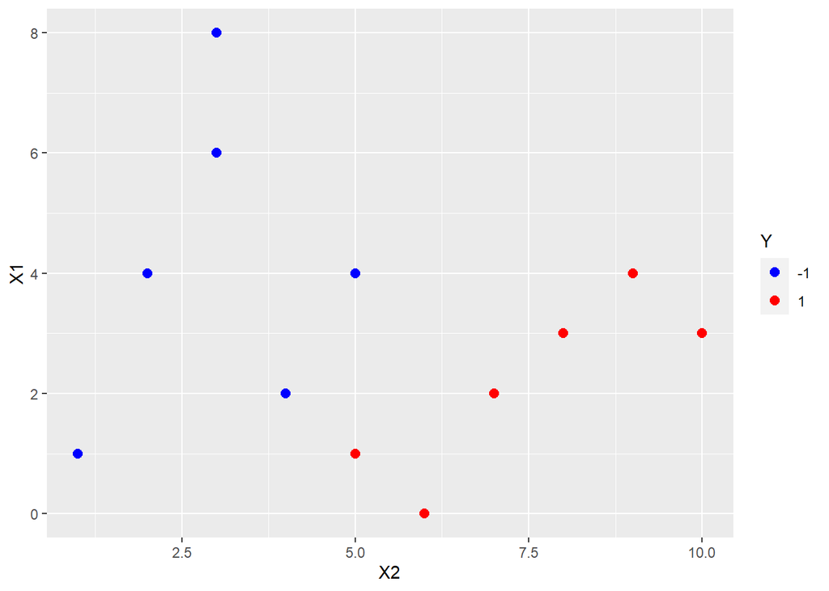

```r
## Question 1 - Scatter plot

scatter_plot <- ggplot(df, aes(x=X2, y=X1, color=Y)) +
  geom_point(shape=19, size = 2.5) +
  scale_color_manual(values=c('blue','red'))

# display plot

scatter_plot
```

### Provide the equation for the optimal separating hyperplane (in the form whichis similar to equation (4.1) in Topic 2, Week 4).

We can represent the hyperplane formula as: $\boldsymbol{\beta}_{0}+\boldsymbol{\beta}_{1} \boldsymbol{X}_{1}+\boldsymbol{\beta}_{2} \boldsymbol{X}_{2}+\ldots . .+\boldsymbol{\beta}_{p} \boldsymbol{X}_{\boldsymbol{p}}=\mathbf{0}$ With p representing p number of features.

$\beta_{0}$ represents the intercept, $\beta_{1}$ is the first axis, $\beta_{2}$ the second access and so fourth $\beta_{p}$…

The observations at each end of the left or right hyperplane are called support vectors as these are reference points for classificaiton of new observations.

Therefore if we have a point $X$ and we use the equation above, we can identify which side of the hyperplane the value will sit and ultimately use that outcome to classify the observation. For example:

If we can Y has 2 classes ${-1, 1}$. This is what can be used for classification in the SVM model.

If $\boldsymbol{\beta}_{0}+\boldsymbol{\beta}_{1} \boldsymbol{X}_{1}+\boldsymbol{\beta}_{2} \boldsymbol{X}_{2}+\ldots . .+\boldsymbol{\beta}_{p} \boldsymbol{X}_{\boldsymbol{p}}<\mathbf{0}$ *if* $yi = -1$ then the observation will be below the line and classified accordingly. Conversely if $\boldsymbol{\beta}_{0}+\boldsymbol{\beta}_{1} \boldsymbol{X}_{1}+\boldsymbol{\beta}_{2} \boldsymbol{X}_{2}+\ldots \ldots+\boldsymbol{\beta}_{p} \boldsymbol{X}_{\boldsymbol{p}} \geq \mathbf{0}$ *if* $y1 = 1$ then it will be classified with the class above the hyperplane.

```r
# Question 2.2

library(quadprog)

X <- as.matrix(df[,c('X2', 'X1')])
y <- as.matrix(Y)
n <- dim(X)[1]

# adding a small value to ensure matrix D is positive definite

eps <- 5e-4

# Build matrices for quadratic solve.QP function

# Create square (n x n) positive definite matrix

Q <- sapply(1:n, function(i) y[i]*t(X)[,i])
D <- t(Q)%*%Q

# linear constant part in objective function

d <- matrix(1, nrow=n)

# column vector for decision vars

b0 <- rbind( matrix(0, nrow=1, ncol=1) , matrix(0, nrow=n, ncol=1) )

# A matrix

A <- t(rbind(matrix(y, nrow=1, ncol=n), diag(nrow=n)))


# Solve using solve.QP()

qp_solve <- solve.QP(D +eps*diag(n), d, A, b0, meq=1, factorized=FALSE)
qp_solution <- matrix(qp_solve$solution, nrow=n)
```

### Sketch the optimal separating hyperplane in the scatter plot obtained in Question 1

We first need to plug the values from our solve/QP() function above into the formula that was discussed in question 2. A function was created to do this.

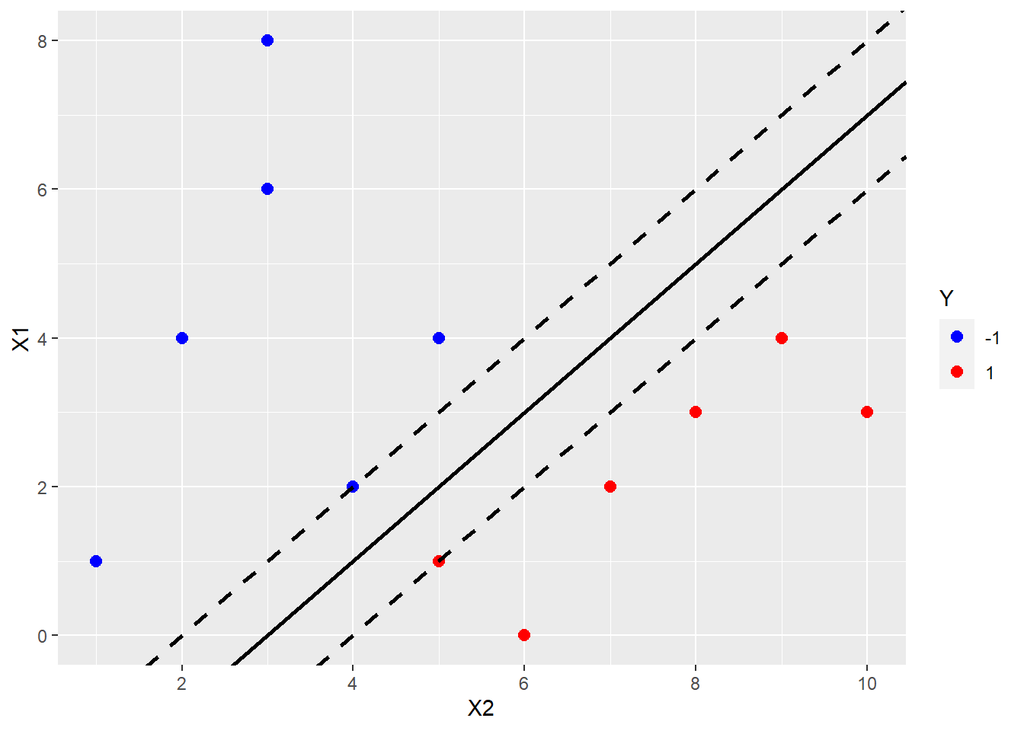

```r
# function to calculate hyperplane for plotting

hyperplane <- function(a, Y, X){
  nonzero <-  abs(a) > 1e-5
  W <- rowSums(sapply(which(nonzero), function(i) a[i]*Y[i]*X[i,]))
  b <- mean(sapply(which(nonzero), function(i) X[i,]%*%W- Y[i]))
  slope <- -W[1]/W[2]
  intercept <- b/W[2]
  return(c(intercept,slope))
}

hyperplane <- hyperplane(qp_solution, Y, X)

# plot the hyperplane


scatter_plot <- ggplot(df, aes(x=X2, y=X1, color=Y)) +
  geom_point(shape=19, size = 2.5) +
  scale_color_manual(values=c('blue','red')) +
  geom_abline(intercept=hyperplane[1] + 1, slope=hyperplane[2], size=1, linetype = "dashed") +
  geom_abline(intercept=hyperplane[1], slope=hyperplane[2], size=1) +
  geom_abline(intercept=hyperplane[1] - 1, slope=hyperplane[2], size=1, linetype = "dashed") +
  scale_x_continuous(breaks = seq(0,10,2))


scatter_plot
```

# Part II: An application

We will first load the data into R and do some basic exploration and manipulation of the response variable to make it clearer.

```r
library("readxl")


setwd("C:/Users/david/OneDrive/University/Data Mining and Machine Learning/Assessment 2")
credit_df <- read_excel("CreditCard_Data.xls", col_names = TRUE)

# Prep data for modelling

str(credit_df)
```

```
## tibble [30,000 x 25] (S3: tbl_df/tbl/data.frame)
##  $ ID                        : num [1:30000] 1 2 3 4 5 6 7 8 9 10 ...
##  $ LIMIT_BAL                 : num [1:30000] 20000 120000 90000 50000 50000 50000 500000 100000 140000 20000 ...
##  $ SEX                       : num [1:30000] 2 2 2 2 1 1 1 2 2 1 ...
##  $ EDUCATION                 : num [1:30000] 2 2 2 2 2 1 1 2 3 3 ...
##  $ MARRIAGE                  : num [1:30000] 1 2 2 1 1 2 2 2 1 2 ...
##  $ AGE                       : num [1:30000] 24 26 34 37 57 37 29 23 28 35 ...
##  $ PAY_0                     : num [1:30000] 2 -1 0 0 -1 0 0 0 0 -2 ...
##  $ PAY_2                     : num [1:30000] 2 2 0 0 0 0 0 -1 0 -2 ...
##  $ PAY_3                     : num [1:30000] -1 0 0 0 -1 0 0 -1 2 -2 ...
##  $ PAY_4                     : num [1:30000] -1 0 0 0 0 0 0 0 0 -2 ...
##  $ PAY_5                     : num [1:30000] -2 0 0 0 0 0 0 0 0 -1 ...
##  $ PAY_6                     : num [1:30000] -2 2 0 0 0 0 0 -1 0 -1 ...
##  $ BILL_AMT1                 : num [1:30000] 3913 2682 29239 46990 8617 ...
##  $ BILL_AMT2                 : num [1:30000] 3102 1725 14027 48233 5670 ...
##  $ BILL_AMT3                 : num [1:30000] 689 2682 13559 49291 35835 ...
##  $ BILL_AMT4                 : num [1:30000] 0 3272 14331 28314 20940 ...
##  $ BILL_AMT5                 : num [1:30000] 0 3455 14948 28959 19146 ...
##  $ BILL_AMT6                 : num [1:30000] 0 3261 15549 29547 19131 ...
##  $ PAY_AMT1                  : num [1:30000] 0 0 1518 2000 2000 ...
##  $ PAY_AMT2                  : num [1:30000] 689 1000 1500 2019 36681 ...
##  $ PAY_AMT3                  : num [1:30000] 0 1000 1000 1200 10000 657 38000 0 432 0 ...
##  $ PAY_AMT4                  : num [1:30000] 0 1000 1000 1100 9000 ...
##  $ PAY_AMT5                  : num [1:30000] 0 0 1000 1069 689 ...
##  $ PAY_AMT6                  : num [1:30000] 0 2000 5000 1000 679 ...
##  $ default payment next month: num [1:30000] 1 1 0 0 0 0 0 0 0 0 ...
```

```r
# rename response variable

colnames(credit_df)[25] <- "default_outcome"

# response variable as factor

credit_df$default_outcome <- as.factor(credit_df$default_outcome)

# Look for NA's

apply(credit_df, 2, function(x) sum(is.na(x)))
```

```
##              ID       LIMIT_BAL             SEX       EDUCATION        MARRIAGE
##               0               0               0               0               0
##             AGE           PAY_0           PAY_2           PAY_3           PAY_4
##               0               0               0               0               0
##           PAY_5           PAY_6       BILL_AMT1       BILL_AMT2       BILL_AMT3
##               0               0               0               0               0
##       BILL_AMT4       BILL_AMT5       BILL_AMT6        PAY_AMT1        PAY_AMT2
##               0               0               0               0               0
##        PAY_AMT3        PAY_AMT4        PAY_AMT5        PAY_AMT6 default_outcome
##               0               0               0               0               0
```

We now create training and test indexes which can be used on the credit_df dataset. These indexes have been used multiple times throughout the markdown file for both tree based algorithms and support vectors.

```r
# 2.2.1

# Split the data into a train and test sets

no_observations <- dim(credit_df)[1] # No. observations (30,000)
no_predictors <- dim(credit_df)[2] - 1 # No. predictors (24) = No. variables (23) - dependent var. (last column)

# testindex a random sample of 30% of no_observations

set.seed(101)
test_index <- sample(no_observations, size=as.integer(no_observations*0.3), replace=FALSE) # 30% test index
training_index <- -test_index # Remaining 70% data observations for training
```